# tutorials_test

- To set up, run: mamba activate oggm_env
- Using oggm_env (Python 3.12.2) kernel

```
2024-04-05 13:57:52: oggm.cfg: Reading default parameters from the OGGM `params.cfg` configuration file.
2024-04-05 13:57:52: oggm.cfg: Multiprocessing switched OFF according to the parameter file.
2024-04-05 13:57:52: oggm.cfg: Multiprocessing: using all available processors (N=2)
```

```
'/home/codespace/.oggm_config'
```

```
2024-04-05 13:57:52: oggm.cfg: Reading default parameters from the OGGM `params.cfg` configuration file.
2024-04-05 13:57:52: oggm.cfg: Multiprocessing switched OFF according to the parameter file.
2024-04-05 13:57:52: oggm.cfg: Multiprocessing: using all available processors (N=2)
```

```
(5.0, 900.0, False)
```

```
2024-04-05 13:57:52: oggm.cfg: Multiprocessing switched ON after user settings.
```

## Working through a mock workflow

Each OGGM run needs a single folder where to store the results of the computations for all glaciers. This is called a “working directory” and needs to be specified before each run. Here we create a temporary folder for you:

```
'/tmp/OGGM/OGGM-GettingStarted-10m'
```

In the OGGM design, this working directory is meant to be persistent, at least as long as you need the data. For example, you can stop your processing workflow after any task, and restart from an existing working directory at a later stage, simply by using the same working directory.

For an operational run on an RGI region, you might want to download the Randolph Glacier Inventory dataset instead, and start a run from it. This case is covered in the working with the RGI tutorial.

## Glacier directories

The OGGM workflow is organized as a list of tasks that have to be applied to a list of glaciers. The vast majority of tasks are called entity tasks: they are standalone operations to be realized on one single glacier entity. These tasks are executed sequentially (one after another): they often need input generated by the previous task(s): for example, the climate calibration needs the glacier flowlines, which can be only computed after the topography data has been processed, and so on.

To handle this situation, OGGM uses a workflow based on data persistence on disk: instead of passing data as python variables from one task to another, each task will read the data from disk and then write the computation results back to the disk, making these new data available for the next task in the queue. These glacier specific data are located in glacier directories.

```
'https://cluster.klima.uni-bremen.de/~oggm/gdirs/oggm_v1.6/L3-L5_files/2023.3/elev_bands/W5E5_spinup'
```

```
2024-04-05 13:57:53: oggm.workflow: init_glacier_directories from prepro level 4 on 2 glaciers.
2024-04-05 13:57:53: oggm.workflow: Execute entity tasks [gdir_from_prepro] on 2 glaciers
```

```
2024-04-05 13:57:54: oggm.workflow: init_glacier_directories from prepro level 4 on 1 glaciers.
2024-04-05 13:57:54: oggm.workflow: Execute entity tasks [gdir_from_prepro] on 1 glaciers
```

- the keyword from_prepro_level indicates that we will start from pre-processed directories, i.e. data that are already prepared by the OGGM team. In many cases you will want to start from pre-processed directories, in most case from level 3 or 5. For level 3 and above the model has already been calibrated, so you no longer need to do that yourself and can start rigth away with your simulation. Here we start from level 4 and add some data to the processing in order to demonstrate the OGGM workflow.
- the prepro_border keyword indicates the number of grid points which we’d like to add to each side of the glacier for the local map: the larger the glacier will grow, the larger the border parameter should be. The available pre-processed border values are: 10, 80, 160, 240 (depending on the model set-ups there might be more or less options). These are the fixed map sizes we prepared for you - any other map size will require a full processing (see the further DEM sources example for a tutorial).

```
(list, oggm.utils._workflow.GlacierDirectory)
```

```
Path to the DEM: /tmp/OGGM/OGGM-GettingStarted-10m/per_glacier/RGI60-11/RGI60-11.01/RGI60-11.01328/dem.tif
Path to the DEM: /tmp/OGGM/OGGM-GettingStarted-10m/per_glacier/RGI60-17/RGI60-17.13/RGI60-17.13045/dem.tif
```

```
<oggm.GlacierDirectory>
  RGI id: RGI60-17.13045
  Region: 17: Southern Andes
  Subregion: 17-02: C Andes
  Glacier type: Ice cap
  Terminus type: Land-terminating
  Status: Glacier or ice cap
  Area: 1.256 km2
  Lon, Lat: (-71.4149, -36.8356)
  Grid (nx, ny): (219, 217)
  Grid (dx, dy): (26.0, -26.0)
```

```
2000
```

The advantage of this Glacier Directory data model is that it simplifies greatly the data transfer between tasks. The single mandatory argument of most OGGM commands will allways be a glacier directory. With the glacier directory, each OGGM task will find the input it needs: for example, both the glacier’s topography and outlines are needed for the next plotting function, and both are available via the gdir argument:

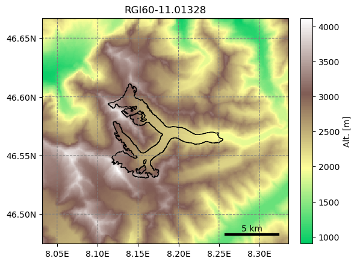

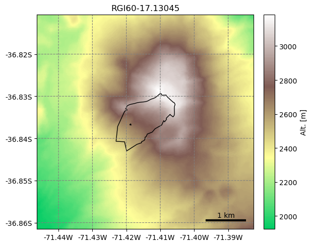

Another advantage of glacier directories is their persistence on disk: once created, they can be recovered from the same location by using init_glacier_directories again, but without keyword arguments:

```
2024-04-05 13:57:56: oggm.workflow: Execute entity tasks [GlacierDirectory] on 1 glaciers
```

Accessing data in the preprocessed directories Glacier directories are the central object for model users and developpers to access data for this glacier. Let’s say for example that you would like to retrieve the climate data that we have prepared for you. You can ask the glacier directory to tell you where this data is:

```
'/tmp/OGGM/OGGM-GettingStarted-10m/per_glacier/RGI60-17/RGI60-17.13/RGI60-17.13045/climate_historical.nc'
```

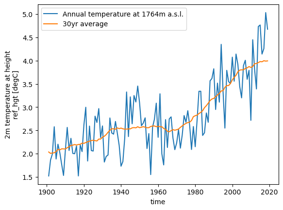

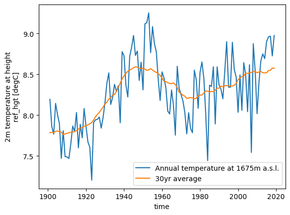

```
['model_diagnostics_spinup_historical.nc', 'fl_diagnostics_spinup_historical.nc', 'fl_diagnostics_historical.nc', 'model_flowlines.pkl', 'model_geometry_historical.nc', 'model_flowlines_dyn_melt_f_calib.pkl', 'model_diagnostics_historical.nc', 'gridded_data.nc', 'inversion_flowlines.pkl', 'elevation…
['model_diagnostics_spinup_historical.nc', 'fl_diagnostics_spinup_historical.nc', 'fl_diagnostics_historical.nc', 'model_flowlines.pkl', 'model_geometry_historical.nc', 'model_flowlines_dyn_melt_f_calib.pkl', 'model_diagnostics_historical.nc', 'gridded_data.nc', 'inversion_flowlines.pkl', 'elevation…
```

OGGM tasks There are two different types of “tasks” in OGGM:

Entity Tasks : Standalone operations to be realized on one single glacier entity, independently from the others. The majority of OGGM tasks are entity tasks. They are parallelisable: the same task can run on several glaciers in parallel.

Global Tasks : Tasks which require to work on several glacier entities at the same time. Model parameter calibration or the compilation of several glaciers’ output are examples of global tasks.

OGGM implements a simple mechanism to run a specific task on a list of GlacierDirectory objects. Here, for the sake of the demonstration of how tasks work, we are going to compute something new from the directory:

```
2024-04-05 13:57:57: oggm.workflow: Execute entity tasks [compute_inversion_velocities] on 2 glaciers
```

```
2024-04-05 13:57:57: oggm.workflow: Execute entity tasks [compute_inversion_velocities] on 1 glaciers
```

Compute inversion velocities is an optional task in the OGGM workflow. It computes the ice velocity along the flowline resulting from the ice flux from a glacier in equilibrium (more on this in the documentation or the dedicated tutorial).

Note that OGGM tasks often do not return anything (the statement above seems to be “void”, i.e. doing nothing). The vast majority of OGGM tasks actually write data to disk in order to retrieve it later. Let’s have a look at the data we just added to the directory:

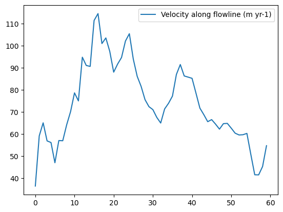

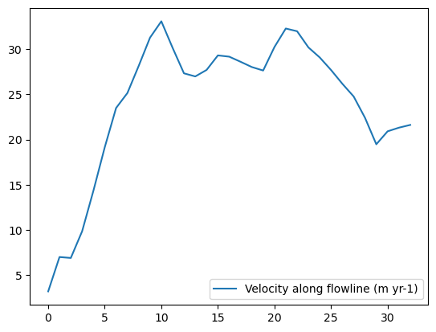

### 10 minutes to… “elevation band” and “centerline” flowlines

https://oggm.org/tutorials/stable/notebooks/10minutes/elevation_bands_vs_centerlines.html

```
2024-04-05 13:57:58: oggm.cfg: Reading default parameters from the OGGM `params.cfg` configuration file.
2024-04-05 13:57:58: oggm.cfg: Multiprocessing switched OFF according to the parameter file.
2024-04-05 13:57:58: oggm.cfg: Multiprocessing: using all available processors (N=2)
```

```
2024-04-05 13:57:58: oggm.workflow: init_glacier_directories from prepro level 3 on 1 glaciers.
2024-04-05 13:57:58: oggm.workflow: Execute entity tasks [gdir_from_prepro] on 1 glaciers
```

```
2024-04-05 13:57:59: oggm.workflow: init_glacier_directories from prepro level 3 on 1 glaciers.
2024-04-05 13:57:59: oggm.workflow: Execute entity tasks [gdir_from_prepro] on 1 glaciers
```

```
<oggm.GlacierDirectory>
  RGI id: RGI60-17.13045
  Region: 17: Southern Andes
  Subregion: 17-02: C Andes
  Glacier type: Ice cap
  Terminus type: Land-terminating
  Status: Glacier or ice cap
  Area: 1.256 km2
  Lon, Lat: (-71.4149, -36.8356)
  Grid (nx, ny): (219, 217)
  Grid (dx, dy): (26.0, -26.0)
```

```
2024-04-05 13:58:00: oggm.workflow: init_glacier_directories from prepro level 3 on 1 glaciers.
2024-04-05 13:58:00: oggm.workflow: Execute entity tasks [gdir_from_prepro] on 1 glaciers
```

```
<oggm.GlacierDirectory>
  RGI id: RGI60-14.06794
  Region: 14: South Asia West
  Subregion: 14-02: Karakoram
  Name: Baltoro Glacier
  Glacier type: Glacier
  Terminus type: Land-terminating
  Status: Glacier or ice cap
  Area: 809.109 km2
  Lon, Lat: (76.4047, 35.7416)
  Grid (nx, ny): (479, 346)
  Grid (dx, dy): (200.0, -200.0)
```

```
2024-04-05 13:58:01: oggm.workflow: init_glacier_directories from prepro level 3 on 1 glaciers.
2024-04-05 13:58:01: oggm.workflow: Execute entity tasks [gdir_from_prepro] on 1 glaciers
```

```
<oggm.GlacierDirectory>
  RGI id: RGI60-17.13045
  Region: 17: Southern Andes
  Subregion: 17-02: C Andes
  Glacier type: Ice cap
  Terminus type: Land-terminating
  Status: Glacier or ice cap
  Area: 1.256 km2
  Lon, Lat: (-71.4149, -36.8356)
  Grid (nx, ny): (219, 217)
  Grid (dx, dy): (26.0, -26.0)
```

## Glacier length and cross section

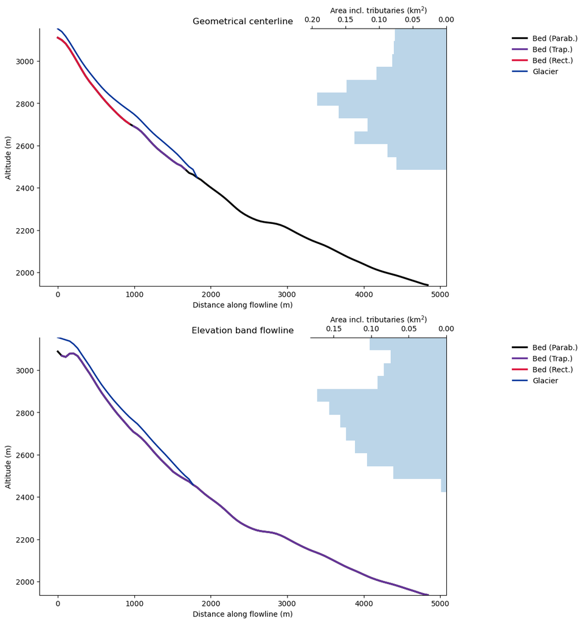

```
2024-04-05 13:58:02: oggm.workflow: Execute entity tasks [process_monthly_isimip_data] on 1 glaciers
```

```
2024-04-05 13:58:03: oggm.workflow: Execute entity tasks [process_monthly_isimip_data] on 1 glaciers
2024-04-05 13:58:04: oggm.workflow: Execute entity tasks [process_monthly_isimip_data] on 1 glaciers
```

For the ice dynamics simulations, the commands are exactly the same as well. The only difference is that centerlines require the more flexible “FluxBased” numerical model, while the elevation bands can also use the more robust “SemiImplicit” one. The runs are considerabily faster with the elevation bands flowlines.

```
2024-04-05 13:58:06: oggm.cfg: PARAMS['store_model_geometry'] changed from `False` to `True`.
2024-04-05 13:58:06: oggm.cfg: PARAMS['store_fl_diagnostics'] changed from `False` to `True`.
2024-04-05 13:58:06: oggm.workflow: Execute entity tasks [run_from_climate_data] on 1 glaciers
2024-04-05 13:58:06: oggm.workflow: Execute entity tasks [run_from_climate_data] on 1 glaciers
2024-04-05 13:58:07: oggm.workflow: Execute entity tasks [run_from_climate_data] on 1 glaciers
2024-04-05 13:58:08: oggm.workflow: Execute entity tasks [run_from_climate_data] on 1 glaciers
```

[output not shown]

[output cut: 68 more lines]

[output not shown]

[figure not shown]

## Last tutorial for tonight: changing it directly to Glaciar Nevado

Display glacier area and thickness changes on a grid

```
2024-04-05 13:59:06: oggm.cfg: Reading default parameters from the OGGM `params.cfg` configuration file.
2024-04-05 13:59:06: oggm.cfg: Multiprocessing switched OFF according to the parameter file.
2024-04-05 13:59:06: oggm.cfg: Multiprocessing: using all available processors (N=2)
```

```
2024-04-05 13:59:06: oggm.workflow: init_glacier_directories from prepro level 4 on 1 glaciers.
2024-04-05 13:59:06: oggm.workflow: Execute entity tasks [gdir_from_prepro] on 1 glaciers
```

## Experiment: a random warming simulation

Here we use a random climate, but you can use any GCM, as long as glaciers are getting smaller, not bigger!

Redistribute: preprocessing The required tasks can be found in the distribute_2d module of the sandbox:

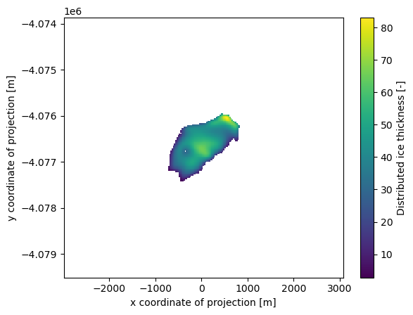

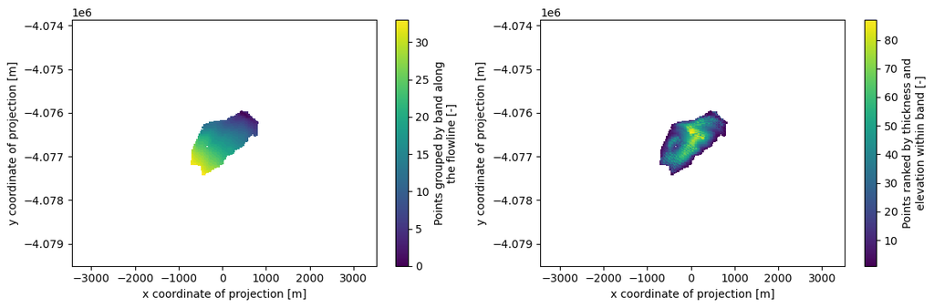

Redistribute simulation The tasks above need to be run only once. The next one however should be done for each simulation:

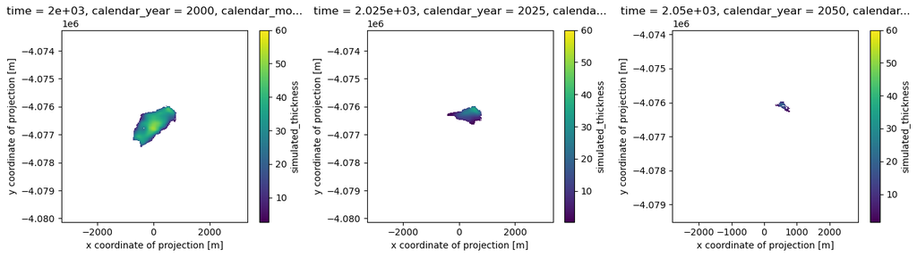

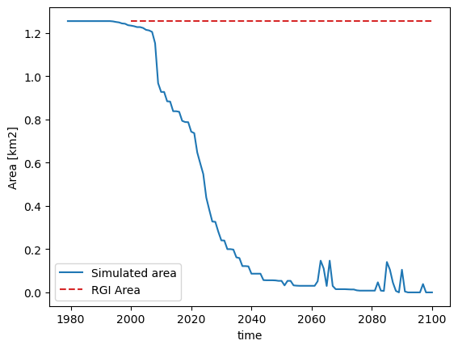

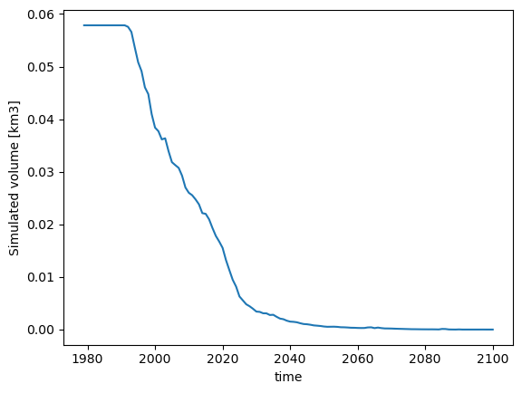

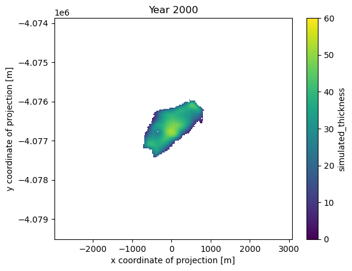